# Male and female suicide rates

The present notebook is presenting some summaries and plots based on the two files from the Gapminder website:

- [Suicide rates for men from WHO (per 100,000 people)](https://spreadsheets.google.com/pub?key=tB8ge4cxd8TL7yIV4ALm5NA&output=xls)
- [Suicide rates for women from WHO (per 100,000 people)](https://spreadsheets.google.com/pub?key=tUD6kmYmB_Bp85SRdEn1Krg&output=xls)

The first thing is to print out fragments of the data and some introductory statistics, in order to become acquainted with the datasets:

|  | Suicide.among.men..per.100.000..age.adjusted | X1950 | X1951 | X1952 | X1953 | X1954 | X1955 | X1956 | X1957 | X1958 | X1959 | X1960 | X1961 | X1962 | X1963 | X1964 | X1965 | X1966 | X1967 | X1968 | X1969 | X1970 | X1971 | X1972 | X1973 | X1974 | X1975 | X1976 | X1977 | … |
| --- | --- | --- | --- | --- | --- | --- | --- | --- | --- | --- | --- | --- | --- | --- | --- | --- | --- | --- | --- | --- | --- | --- | --- | --- | --- | --- | --- | --- | --- | --- |
| 1 | Afghanistan | NA | NA | NA | NA | NA | NA | NA | NA | NA | NA | NA | NA | NA | NA | NA | NA | NA | NA | NA | NA | NA | NA | NA | NA | NA | NA | NA | NA | … |
| 2 | Albania | NA | NA | NA | NA | NA | NA | NA | NA | NA | NA | NA | NA | NA | NA | NA | NA | NA | NA | NA | NA | NA | NA | NA | NA | NA | NA | NA | NA | … |
| 3 | Algeria | NA | NA | NA | NA | NA | NA | NA | NA | NA | NA | NA | NA | NA | NA | NA | NA | NA | NA | NA | NA | NA | NA | NA | NA | NA | NA | NA | NA | … |
| 4 | Andorra | NA | NA | NA | NA | NA | NA | NA | NA | NA | NA | NA | NA | NA | NA | NA | NA | NA | NA | NA | NA | NA | NA | NA | NA | NA | NA | NA | NA | … |
| 5 | Angola | NA | NA | NA | NA | NA | NA | NA | NA | NA | NA | NA | NA | NA | NA | NA | NA | NA | NA | NA | NA | NA | NA | NA | NA | NA | NA | NA | NA | … |
| 6 | Antigua and Barbuda | NA | NA | NA | NA | NA | NA | NA | NA | NA | NA | NA | NA | NA | NA | NA | NA | NA | NA | NA | NA | NA | NA | NA | NA | NA | NA | NA | NA | … |

```r
summary(suicide_male)
```

```
 Suicide.among.men..per.100.000..age.adjusted     X1950            X1951            X1952
 Afghanistan        :  1                      Min.   : 4.258   Min.   : 4.003   Min.   : 3.379
 Albania            :  1                      1st Qu.:11.285   1st Qu.: 9.673   1st Qu.: 9.616
 Algeria            :  1                      Median :13.201   Median :11.812   Median :15.443
 Andorra            :  1                      Mean   :14.667   Mean   :15.042   Mean   :16.849
 Angola             :  1                      3rd Qu.:16.807   3rd Qu.:17.899   3rd Qu.:23.527
 Antigua and Barbuda:  1                      Max.   :31.452   Max.   :31.320   Max.   :32.923
 (Other)            :192                      NA's   :188      NA's   :182      NA's   :179
     X1953            X1954            X1955            X1956            X1957            X1958
 Min.   : 1.927   Min.   : 3.258   Min.   : 2.442   Min.   : 2.222   Min.   : 1.509   Min.   : 3.744
 1st Qu.:10.189   1st Qu.:10.229   1st Qu.:10.913   1st Qu.:12.503   1st Qu.:10.881   1st Qu.:10.885
 Median :14.081   Median :14.767   Median :15.493   Median :15.957   Median :15.775   Median :16.097
 Mean   :17.170   Mean   :17.617   Mean   :17.518   Mean   :18.202   Mean   :17.994   Mean   :17.996
 3rd Qu.:25.090   3rd Qu.:24.749   3rd Qu.:24.424   3rd Qu.:27.581   3rd Qu.:27.505   3rd Qu.:24.582
 Max.   :32.949   Max.   :34.312   Max.   :35.882   Max.   :40.358   Max.   :38.269   Max.   :36.833
 NA's   :177      NA's   :176      NA's   :169      NA's   :169      NA's   :169      NA's   :169
     X1959            X1960           X1961            X1962            X1963            X1964
 Min.   : 3.957   Min.   : 3.81   Min.   : 3.787   Min.   : 2.988   Min.   : 3.790   Min.   : 3.540
 1st Qu.:10.962   1st Qu.:10.44   1st Qu.: 8.615   1st Qu.: 8.036   1st Qu.: 8.185   1st Qu.: 8.268
 Median :16.276   Median :15.62   Median :15.592   Median :14.440   Median :15.928   Median :14.878
 Mean   :18.009   Mean   :17.54   Mean   :16.495   Mean   :16.196   Mean   :16.169   Mean   :16.276
 3rd Qu.:23.972   3rd Qu.:23.62   3rd Qu.:22.700   3rd Qu.:22.869   3rd Qu.:23.226   3rd Qu.:23.709
 Max.   :37.932   Max.   :35.66   Max.   :36.410   Max.   :37.739   Max.   :37.487   Max.   :40.131
 NA's   :169      NA's   :168     NA's   :167      NA's   :166      NA's   :163      NA's   :162
     X1965            X1966            X1967            X1968            X1969            X1970
 Min.   : 3.148   Min.   : 3.493   Min.   : 3.728   Min.   : 3.523   Min.   : 1.750   Min.   : 2.705
 1st Qu.: 9.211   1st Qu.: 9.711   1st Qu.: 8.521   1st Qu.: 9.187   1st Qu.: 9.161   1st Qu.: 9.679
 Median :16.654   Median :15.591   Median :15.632   Median :16.782   Median :16.615   Median :15.866
 Mean   :16.436   Mean   :16.597   Mean   :16.831   Mean   :17.399   Mean   :16.807   Mean   :17.113
 3rd Qu.:22.236   3rd Qu.:22.047   3rd Qu.:22.247   3rd Qu.:23.015   3rd Qu.:21.802   3rd Qu.:20.280
 Max.   :41.366   Max.   :40.384   Max.   :43.316   Max.   :46.686   Max.   :45.462   Max.   :47.394
 NA's   :163      NA's   :162      NA's   :161      NA's   :159      NA's   :161      NA's   :162
     X1971            X1972             X1973            X1974            X1975             X1976
 Min.   : 1.673   Min.   : 0.3662   Min.   : 0.115   Min.   : 0.000   Min.   : 0.1955   Min.   : 0.1452
 1st Qu.: 9.262   1st Qu.: 8.3482   1st Qu.:10.484   1st Qu.: 8.918   1st Qu.: 9.1951   1st Qu.: 9.2821
 Median :17.213   Median :16.8588   Median :17.385   Median :16.668   Median :15.1549   Median :15.6889
 Mean   :17.303   Mean   :17.2073   Mean   :18.083   Mean   :17.704   Mean   :17.0343   Mean   :16.9889
 3rd Qu.:21.095   3rd Qu.:22.5217   3rd Qu.:25.354   3rd Qu.:24.545   3rd Qu.:21.7003   3rd Qu.:21.3450
 Max.   :48.453   Max.   :49.4027   Max.   :49.389   Max.   :53.981   Max.   :51.0996   Max.   :52.8212
 NA's   :163      NA's   :162       NA's   :162      NA's   :160      NA's   :160       NA's   :160
```

[output cut: 25 more lines]

```
 Min.   : 1.403   Min.   : 1.096   Min.   : 1.482   Min.   : 0.00   Min.   : 0.00   Min.   : 0.00
 1st Qu.:10.726   1st Qu.:10.667   1st Qu.:10.767   1st Qu.:10.07   1st Qu.:10.09   1st Qu.: 9.60
 Median :18.749   Median :19.260   Median :19.129   Median :18.83   Median :18.15   Median :18.04
 Mean   :22.263   Mean   :22.559   Mean   :22.867   Mean   :21.03   Mean   :21.05   Mean   :21.21
 3rd Qu.:27.370   3rd Qu.:27.059   3rd Qu.:26.987   3rd Qu.:23.33   3rd Qu.:23.61   3rd Qu.:25.43
 Max.   :72.055   Max.   :80.429   Max.   :77.844   Max.   :78.37   Max.   :76.53   Max.   :72.59
 NA's   :139      NA's   :138      NA's   :139      NA's   :138     NA's   :136     NA's   :135
     X1999            X2000            X2001            X2002            X2003            X2004
 Min.   : 0.000   Min.   : 0.000   Min.   : 0.000   Min.   : 1.756   Min.   : 3.328   Min.   : 0.000
 1st Qu.: 9.452   1st Qu.: 8.631   1st Qu.: 9.734   1st Qu.:10.472   1st Qu.:10.964   1st Qu.: 6.884
 Median :18.415   Median :16.839   Median :16.709   Median :17.884   Median :16.523   Median :12.400
 Mean   :20.072   Mean   :18.747   Mean   :19.242   Mean   :20.789   Mean   :20.882   Mean   :14.228
 3rd Qu.:23.914   3rd Qu.:23.391   3rd Qu.:23.072   3rd Qu.:24.402   3rd Qu.:24.705   3rd Qu.:18.629
 Max.   :73.372   Max.   :75.079   Max.   :71.129   Max.   :74.296   Max.   :67.592   Max.   :63.309
 NA's   :133      NA's   :133      NA's   :136      NA's   :139      NA's   :143      NA's   :5
```

|  | Suicide.women.age.adjusted | X1950 | X1951 | X1952 | X1953 | X1954 | X1955 | X1956 | X1957 | X1958 | X1959 | X1960 | X1961 | X1962 | X1963 | X1964 | X1965 | X1966 | X1967 | X1968 | X1969 | X1970 | X1971 | X1972 | X1973 | X1974 | X1975 | X1976 | X1977 | … |
| --- | --- | --- | --- | --- | --- | --- | --- | --- | --- | --- | --- | --- | --- | --- | --- | --- | --- | --- | --- | --- | --- | --- | --- | --- | --- | --- | --- | --- | --- | --- |
| 1 | Afghanistan | NA | NA | NA | NA | NA | NA | NA | NA | NA | NA | NA | NA | NA | NA | NA | NA | NA | NA | NA | NA | NA | NA | NA | NA | NA | NA | NA | NA | … |
| 2 | Albania | NA | NA | NA | NA | NA | NA | NA | NA | NA | NA | NA | NA | NA | NA | NA | NA | NA | NA | NA | NA | NA | NA | NA | NA | NA | NA | NA | NA | … |
| 3 | Algeria | NA | NA | NA | NA | NA | NA | NA | NA | NA | NA | NA | NA | NA | NA | NA | NA | NA | NA | NA | NA | NA | NA | NA | NA | NA | NA | NA | NA | … |
| 4 | Andorra | NA | NA | NA | NA | NA | NA | NA | NA | NA | NA | NA | NA | NA | NA | NA | NA | NA | NA | NA | NA | NA | NA | NA | NA | NA | NA | NA | NA | … |
| 5 | Angola | NA | NA | NA | NA | NA | NA | NA | NA | NA | NA | NA | NA | NA | NA | NA | NA | NA | NA | NA | NA | NA | NA | NA | NA | NA | NA | NA | NA | … |
| 6 | Antigua and Barbuda | NA | NA | NA | NA | NA | NA | NA | NA | NA | NA | NA | NA | NA | NA | NA | NA | NA | NA | NA | NA | NA | NA | NA | NA | NA | NA | NA | NA | … |

```r
summary(suicide_female)
```

```
       Suicide.women.age.adjusted     X1950             X1951            X1952             X1953
 Afghanistan        :  1          Min.   : 0.8519   Min.   : 1.148   Min.   : 0.8796   Min.   : 0.3979
 Albania            :  1          1st Qu.: 3.9289   1st Qu.: 3.281   1st Qu.: 3.5925   1st Qu.: 3.7396
 Algeria            :  1          Median : 4.7596   Median : 4.568   Median : 5.0831   Median : 5.4561
 Andorra            :  1          Mean   : 5.7157   Mean   : 5.931   Mean   : 6.2225   Mean   : 6.3617
 Angola             :  1          3rd Qu.: 5.2783   3rd Qu.: 5.992   3rd Qu.: 6.3471   3rd Qu.: 8.1118
 Antigua and Barbuda:  1          Max.   :18.5910   Max.   :17.542   Max.   :17.7080   Max.   :18.7084
 (Other)            :192          NA's   :188       NA's   :182      NA's   :179       NA's   :177
     X1954             X1955             X1956            X1957             X1958            X1959
 Min.   : 0.7037   Min.   : 0.3915   Min.   : 0.334   Min.   : 0.2548   Min.   : 1.091   Min.   : 1.154
 1st Qu.: 3.5755   1st Qu.: 2.9516   1st Qu.: 3.441   1st Qu.: 2.7941   1st Qu.: 3.268   1st Qu.: 3.472
 Median : 5.6123   Median : 5.3187   Median : 5.729   Median : 5.6789   Median : 5.405   Median : 5.790
 Mean   : 6.3943   Mean   : 6.3852   Mean   : 6.603   Mean   : 6.4650   Mean   : 6.546   Mean   : 6.527
 3rd Qu.: 7.5968   3rd Qu.: 8.4874   3rd Qu.: 9.487   3rd Qu.: 9.3591   3rd Qu.: 9.759   3rd Qu.: 8.416
 Max.   :19.7812   Max.   :20.9291   Max.   :21.072   Max.   :20.5632   Max.   :21.983   Max.   :19.978
 NA's   :176       NA's   :169       NA's   :169      NA's   :169       NA's   :169      NA's   :169
     X1960            X1961             X1962             X1963             X1964
 Min.   : 1.267   Min.   : 0.8261   Min.   : 0.7359   Min.   : 0.3511   Min.   : 0.6879
 1st Qu.: 3.372   1st Qu.: 3.0082   1st Qu.: 2.7799   1st Qu.: 2.7735   1st Qu.: 2.8424
 Median : 5.916   Median : 4.5473   Median : 5.3369   Median : 4.7487   Median : 5.4108
 Mean   : 6.536   Mean   : 6.0684   Mean   : 5.9410   Mean   : 5.9380   Mean   : 6.1415
 3rd Qu.: 8.609   3rd Qu.: 8.1687   3rd Qu.: 8.9745   3rd Qu.: 8.7802   3rd Qu.: 9.4928
 Max.   :19.146   Max.   :17.7909   Max.   :15.5424   Max.   :15.2656   Max.   :15.1147
 NA's   :168      NA's   :167       NA's   :166       NA's   :163       NA's   :162
     X1965             X1966             X1967             X1968            X1969
 Min.   : 0.4481   Min.   : 0.3508   Min.   : 0.4273   Min.   : 0.636   Min.   : 0.2342
 1st Qu.: 3.0714   1st Qu.: 3.3965   1st Qu.: 2.9156   1st Qu.: 3.635   1st Qu.: 3.0675
 Median : 5.9757   Median : 5.5454   Median : 5.4781   Median : 6.064   Median : 6.4950
 Mean   : 6.2503   Mean   : 6.4322   Mean   : 6.1510   Mean   : 6.603   Mean   : 6.4447
 3rd Qu.: 9.1469   3rd Qu.: 9.6702   3rd Qu.:10.2097   3rd Qu.: 9.938   3rd Qu.: 9.8541
 Max.   :15.8135   Max.   :15.6408   Max.   :15.6902   Max.   :15.974   Max.   :15.7796
 NA's   :163       NA's   :162       NA's   :161       NA's   :159      NA's   :161
     X1970             X1971             X1972             X1973             X1974
 Min.   : 0.5537   Min.   : 0.3252   Min.   : 0.2315   Min.   : 0.1023   Min.   : 0.03268
 1st Qu.: 3.3703   1st Qu.: 2.7505   1st Qu.: 2.9734   1st Qu.: 3.6737   1st Qu.: 2.95806
 Median : 6.2700   Median : 6.4397   Median : 6.2516   Median : 6.3079   Median : 6.50730
 Mean   : 6.5973   Mean   : 6.7793   Mean   : 6.7037   Mean   : 7.1515   Mean   : 7.27251
 3rd Qu.: 9.3723   3rd Qu.:10.5851   3rd Qu.:10.0590   3rd Qu.:10.1055   3rd Qu.:10.09709
 Max.   :15.9927   Max.   :17.1201   Max.   :17.3790   Max.   :19.2433   Max.   :20.03715
 NA's   :162       NA's   :163       NA's   :162       NA's   :162       NA's   :161
```

[output cut: 33 more lines]

```
 Min.   : 0.1801   Min.   : 0.3849   Min.   : 0.6183   Min.   : 0.4201   Min.   : 0.3349
 1st Qu.: 2.8304   1st Qu.: 2.6669   1st Qu.: 2.4207   1st Qu.: 2.5706   1st Qu.: 2.2949
 Median : 5.7914   Median : 4.7949   Median : 4.7765   Median : 5.2104   Median : 4.7256
 Mean   : 5.8907   Mean   : 5.2975   Mean   : 5.2241   Mean   : 5.3175   Mean   : 5.1675
 3rd Qu.: 8.1332   3rd Qu.: 7.6269   3rd Qu.: 7.8325   3rd Qu.: 8.1223   3rd Qu.: 7.7537
 Max.   :14.0952   Max.   :14.5423   Max.   :12.6671   Max.   :11.8952   Max.   :11.7318
 NA's   :139       NA's   :139       NA's   :137       NA's   :136       NA's   :136
     X2000              X2001             X2002             X2003             X2004
 Min.   : 0.03989   Min.   : 0.6872   Min.   : 0.8555   Min.   : 0.9492   Min.   : 0.1078
 1st Qu.: 2.50528   1st Qu.: 2.4437   1st Qu.: 2.9242   1st Qu.: 3.0709   1st Qu.: 2.9528
 Median : 4.43547   Median : 4.8133   Median : 4.6758   Median : 4.4902   Median : 5.0510
 Mean   : 4.83422   Mean   : 4.8077   Mean   : 5.0099   Mean   : 4.9488   Mean   : 5.5662
 3rd Qu.: 7.47449   3rd Qu.: 6.8728   3rd Qu.: 6.9994   3rd Qu.: 6.7207   3rd Qu.: 7.1703
 Max.   :13.98588   Max.   :12.0488   Max.   :10.1242   Max.   :12.4574   Max.   :26.9730
 NA's   :137        NA's   :139       NA's   :139       NA's   :143       NA's   :8
```

```r
suicide_2004_combined$female <- suicide_female$X2004
```

[output not shown]

Next, we print summary of the data:

```r
summary(new)
```

```
                country        female             male
 Afghanistan        :  1   Min.   : 0.1078   Min.   : 0.000
 Albania            :  1   1st Qu.: 2.9528   1st Qu.: 6.884
 Algeria            :  1   Median : 5.0510   Median :12.400
 Andorra            :  1   Mean   : 5.5662   Mean   :14.228
 Angola             :  1   3rd Qu.: 7.1703   3rd Qu.:18.629
 Antigua and Barbuda:  1   Max.   :26.9730   Max.   :63.309
 (Other)            :192   NA's   :8         NA's   :5
```

In the introductory statistics, we already notice, that the mean and median for male suicide is far larger than the mean and median of female suicide, an observation which would go in hand with theoretical observations on suicide by authors such as Emile Durkheim.

To investigate this phenomenon further, let us plot the data:

```r
library(ggplot)
```

```
Error in library(ggplot) : there is no package called ‘ggplot’
```

```r
p1 <- ggplot(aes(female), data = new) +
  geom_hist()
```

```
Error: could not find function "geom_hist"
```

```r
p2 <- ggplot(aes(male), data = new) +
  geom_histogram(binwidth = 2) +
  scale_x_continuous(breaks = seq(0, 60, 5), limits = c(0, 60)) +
  scale_y_continuous(breaks = seq(0, 50, 5), limits - c(0, 50))
```

```
Error in ggproto(NULL, super, call = match.call(), aesthetics = aesthetics,  :
  object 'limits' not found
```

[figure not shown]

The above observations could be gleamed from the summaries of the data as well, and as such, are not particularly revealing.

What could bring some clarity on the relation between these two counts could be Pearson’s correlation.

```r
with(new, cor.test(male, female))
```

```
    Pearson's product-moment correlation

data:  male and female
t = 9.7689, df = 188, p-value < 2.2e-16
alternative hypothesis: true correlation is not equal to 0
95 percent confidence interval:
 0.4773362 0.6674788
sample estimates:
      cor
0.5802606
```

Pearson’t correlation between the two counts stands at 0.58, which marks quite a significant correlation. While I might be mistaken (the dataset is quite unlike the other sets I have been working on, in its delimited information), this might indicate, that higher female suicide rate indicates higher male suicide rate. Let us follow this trope, and plot the two variables against each other:

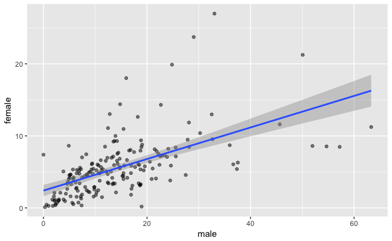

The scatterplot does indeed indicate a definite relation between the two. While the male suicide rate is generally higher than female suicide rate, high percentage of one indicates high percentage of the other.

The following are some variations for the plot above, introducing some aesthetic changes:

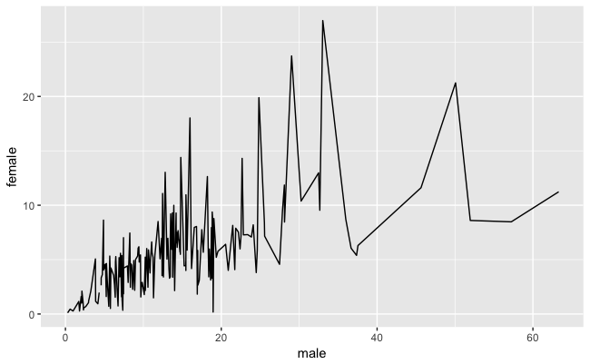

geom_line appears far less informative than the above visualizations.

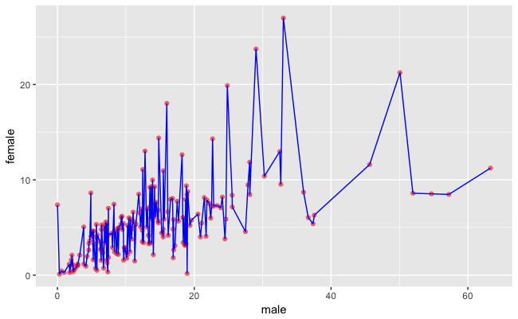

Pretty much the same informational value, and not very visually impressive…